# Phase 3 — Stream A: Bayesian DLNM for Perinatal Mortality

Heat Stress and Perinatal Outcomes in the Navrongo HDSS (Chapter 3)

Vincent

19 June 2026

# 1 Purpose and scope

This document implements Phase 3, the **substantive primary analysis** of Chapter 3 (Stream A): the association between daily heat exposure during pregnancy and **perinatal mortality**, estimated with a Bayesian hierarchical distributed lag non-linear model (DLNM).

The exposure is the daily-maximum UTCI lag matrix (lag 0–30 days pre-delivery) produced and validated by `02_link_era5_utci.Rmd` and `03_phase1_descriptive.Rmd`. The outcome is the perinatal composite (stillbirth or early-neonatal death within 0–7 days), constructed here from the spine’s `child_birth_type` and `died_enn` fields. The model couples a cross-basis on (UTCI × lag) with a covariate adjustment set and mother- and compound-level random intercepts, following the specification in Table 3.3 of Chapter 3.

The script proceeds in five steps: assemble the analytic frame (join the exposure lag matrix to the spine outcomes and covariates); build the cross-basis with knots placed from the observed exposure distribution; fit the Bayesian hierarchical model in `brms`/Stan; extract and plot the exposure–lag–response surface; and identify the critical lag windows.

**Dependency note.** The Stream A primary outcome includes recorded stillbirths (`child_birth_type == 4`). The recorded stillbirth count was still being confirmed with the NHRC data-management team at the time of writing; the script therefore reports the composite count it actually constructs from the supplied extract and is robust to the stillbirth set being sparse or substantial. If the stillbirth coding is revised, only the outcome-construction chunk needs to be re-run.

```r
suppressPackageStartupMessages({
  library(dplyr)
  library(tidyr)
  library(lubridate)
  library(stringr)
  library(ggplot2)
  library(knitr)
  library(kableExtra)
  library(dlnm)        # cross-basis construction
  library(splines)     # ns() for the covariate calendar-time spline
})

# brms / rstan are loaded only when the model is actually fitted, so the
# assembly and cross-basis steps run in environments without a Stan toolchain.
theme_set(theme_minimal(base_size = 12))
```

```r
# ---------------------------------------------------------------------------
# Paths (match the outputs of the earlier scripts).
# ---------------------------------------------------------------------------
OUT_DIR      <- "."
EXPOSURE_RDS <- file.path(OUT_DIR, "exposure.rds")
SPINE_RDS    <- file.path(OUT_DIR, "spine.rds")
MODEL_DIR    <- file.path(OUT_DIR, "models")
dir.create(MODEL_DIR, showWarnings = FALSE, recursive = TRUE)

# ---------------------------------------------------------------------------
# Cross-basis specification (Chapter 3 v8, Table 3.3).
#   Exposure dimension: natural cubic B-spline, 2 df, knots at the 50th and
#                       90th percentiles of the observed daily-max UTCI.
#   Lag dimension:      natural cubic B-spline, 3 df, knots at lags 7 and 21,
#                       over lag 0–30 days.
# ---------------------------------------------------------------------------
LAG_MIN          <- 0L
LAG_MAX          <- 30L
EXPOSURE_KNOT_PCTL <- c(50, 90)     # percentiles for the UTCI spline knots
LAG_KNOTS          <- c(7, 21)      # interior knots for the lag spline
EXPOSURE_REF_PCTL  <- 50           # reference centring percentile for plotting

# ---------------------------------------------------------------------------
# Bayesian sampler settings (Chapter 3 v8, Table 3.3).
# ---------------------------------------------------------------------------
N_CHAINS  <- 4L
N_ITER    <- 4000L
N_WARMUP  <- 2000L
ADAPT_DELTA <- 0.95
MAX_TREEDEPTH <- 12L
SEED      <- 20260618L

# Set FIT_MODEL <- FALSE to assemble the frame and build the cross-basis
# (fast, no Stan needed) without fitting; useful for development and for
# handing a ready-to-fit object to the NHRC compute environment.
FIT_MODEL <- TRUE

nice_table <- function(x, caption = NULL, full_width = FALSE) {
  k <- kable(x, caption = caption, format.args = list(big.mark = ","),
             booktabs = TRUE)
  if (knitr::is_html_output()) {
    kable_styling(k, bootstrap_options = c("striped","hover","condensed"),
                  full_width = full_width, position = "left")
  } else {
    kable_styling(k, latex_options = c("striped","hold_position"),
                  full_width = full_width, position = "left")
  }
}
```

# 2 Assemble the analytic frame

The exposure file carries the daily-max UTCI lag matrix and identifiers; the spine carries the outcome and covariates. They are joined on `child_id`.

```r
exposure <- readRDS("C:/Users/bedia/Downloads/Chapter 3_Dissertation/exposure.rds")
spine    <- readRDS("C:/Users/bedia/Downloads/Chapter 3_Dissertation/spine.rds")

# Outcome and covariate fields needed from the spine for Stream A.
spine_vars <- spine |>
  dplyr::mutate(
    child_birth_type_f = haven::as_factor(child_birth_type)
  ) |>
  dplyr::transmute(
    child_id,
    motherid, locationid,
    child_birth_type_f,
    died_enn,
    stillbirth = dplyr::if_else(
      child_birth_type_f == "stillbirth",
      1L, 0L,
      missing = 0L
    ),
    perinatal = as.integer(
      (child_birth_type_f == "stillbirth" & !is.na(child_birth_type_f)) |
      (died_enn == 1 & !is.na(died_enn))
    ),
    mat_age_yrs,
    educ_any_secondary,
    ses_index,
    nulliparous_proxy,
    child_gender,   # use this, not `gender`
    season3,
    birth_year,
    anc_reliable
  )

frame <- exposure |>
  inner_join(spine_vars, by = "child_id")

cat(sprintf("Exposure rows: %s | spine rows: %s | joined: %s\n",
            format(nrow(exposure), big.mark = ","),
            format(nrow(spine),    big.mark = ","),
            format(nrow(frame),    big.mark = ",")))
```

```
#> Exposure rows: 2,696 | spine rows: 8,876 | joined: 2,696
```

```r
lag_cols <- paste0("lag_", LAG_MIN:LAG_MAX)

frame <- exposure |>
  inner_join(spine_vars, by = "child_id") |>
  dplyr::rename(
    motherid = motherid.y,
    locationid = locationid.y
  ) |>
  dplyr::select(-motherid.x, -locationid.x) |>
  mutate(lag_complete = rowSums(is.na(across(all_of(lag_cols)))) == 0)

complete <- frame |>
  filter(lag_complete,
         !is.na(mat_age_yrs), !is.na(educ_any_secondary),
         !is.na(ses_index), !is.na(nulliparous_proxy),
         !is.na(child_gender), !is.na(season3), !is.na(birth_year),
         !is.na(perinatal)) |>
  dplyr::select(
    child_id, motherid, locationid, perinatal, stillbirth, died_enn,
    mat_age_yrs, educ_any_secondary, ses_index, nulliparous_proxy,
    child_gender, season3, birth_year,
    all_of(lag_cols)
  )

Q <- as.matrix(complete[, lag_cols, drop = FALSE])

exp_knots <- quantile(Q, EXPOSURE_KNOT_PCTL / 100, na.rm = TRUE)
exp_ref   <- quantile(Q, EXPOSURE_REF_PCTL / 100, na.rm = TRUE)

cb <- crossbasis(
  Q,
  lag = c(LAG_MIN, LAG_MAX),
  argvar = list(fun = "ns", knots = exp_knots),
  arglag = list(fun = "ns", knots = LAG_KNOTS)
)

cb_mat <- as.data.frame(cb)
names(cb_mat) <- paste0("cb", seq_len(ncol(cb_mat)))
model_df <- bind_cols(complete, cb_mat)

stopifnot(all(c("motherid", "locationid") %in% names(model_df)))

outcome_tab <- tibble(
  quantity = c("joined pregnancies",
               "with complete lag matrix",
               "with complete covariates (analytic n)",
               "recorded stillbirths (child_birth_type == 4)",
               "early-neonatal deaths (died_enn == 1)",
               "perinatal composite events",
               "perinatal event fraction (%)"),
  value = c(
    format(nrow(frame), big.mark = ","),
    format(sum(frame$lag_complete), big.mark = ","),
    format(nrow(complete), big.mark = ","),
    format(sum(complete$stillbirth, na.rm = TRUE), big.mark = ","),
    format(sum(complete$died_enn,   na.rm = TRUE), big.mark = ","),
    format(sum(complete$perinatal,  na.rm = TRUE), big.mark = ","),
    sprintf("%.2f", 100 * mean(complete$perinatal, na.rm = TRUE))
  )
)
nice_table(outcome_tab,
           caption = "Stream A outcome construction and analytic sample (perinatal = stillbirth or early-neonatal death).")
```

Stream A outcome construction and analytic sample (perinatal = stillbirth or early-neonatal death).

| quantity | value |
| --- | --- |
| joined pregnancies | 2,696 |
| with complete lag matrix | 2,599 |
| with complete covariates (analytic n) | 2,330 |
| recorded stillbirths (child_birth_type == 4) | 0 |
| early-neonatal deaths (died_enn == 1) | 35 |
| perinatal composite events | 35 |
| perinatal event fraction (%) | 1.50 |

The “analytic n” row is the complete-case sample the DLNM is fitted on. The perinatal-event count is the load-bearing figure for Stream A power; the events-per-parameter ratio is reported after the cross-basis is built.

# 3 Build the cross-basis

```r
# Daily-max UTCI lag matrix as a numeric matrix, columns ordered lag_0..lag_30.
Q <- as.matrix(complete[, lag_cols])
colnames(Q) <- NULL

# Knot placement from the observed exposure distribution (recommended over
# hard-coded values so the knots track the data).
exp_knots <- quantile(Q, EXPOSURE_KNOT_PCTL / 100, na.rm = TRUE)
exp_ref   <- quantile(Q, EXPOSURE_REF_PCTL / 100, na.rm = TRUE)

cat(sprintf("Exposure spline knots (p%s, p%s): %.1f °C, %.1f °C\n",
            EXPOSURE_KNOT_PCTL[1], EXPOSURE_KNOT_PCTL[2],
            exp_knots[1], exp_knots[2]))
```

```
#> Exposure spline knots (p50, p90): 39.0 °C, 44.6 °C
```

```r
cat(sprintf("Exposure reference (p%s) for centring: %.1f °C\n",
            EXPOSURE_REF_PCTL, exp_ref))
```

```
#> Exposure reference (p50) for centring: 39.0 °C
```

```r
cat(sprintf("Lag spline interior knots: %s (over lag %d–%d)\n",
            paste(LAG_KNOTS, collapse = ", "), LAG_MIN, LAG_MAX))
```

```
#> Lag spline interior knots: 7, 21 (over lag 0–30)
```

```r
cb <- crossbasis(
  Q,
  lag = c(LAG_MIN, LAG_MAX),
  argvar = list(fun = "ns", knots = exp_knots),
  arglag = list(fun = "ns", knots = LAG_KNOTS)
)

cb_df <- ncol(cb)
n_cov <- 6L + 1L  # covariates below; calendar spline adds df, counted at fit
events <- sum(complete$perinatal, na.rm = TRUE)
cat(sprintf("\nCross-basis columns (df): %d\n", cb_df))
```

```
#>
#> Cross-basis columns (df): 12
```

```r
cat(sprintf("Perinatal events: %s | events per cross-basis df: %.0f:1\n",
            format(events, big.mark = ","), events / cb_df))
```

```
#> Perinatal events: 35 | events per cross-basis df: 3:1
```

```r
# Attach the cross-basis columns to the analytic frame for brms.
cb_mat <- as.data.frame(cb)
names(cb_mat) <- paste0("cb", seq_len(ncol(cb_mat)))
model_df <- bind_cols(complete, cb_mat)
```

# 4 Fit the Bayesian hierarchical DLNM

```r
suppressPackageStartupMessages({
  library(brms)
})

cb_terms <- paste(names(cb_mat), collapse = " + ")

# Calendar year as a natural cubic spline (flexible secular-trend control).
form <- bf(as.formula(paste0(
  "perinatal ~ ", cb_terms,
  " + scale(mat_age_yrs) + educ_any_secondary + scale(ses_index)",
  " + nulliparous_proxy + child_gender + season3",
  " + ns(birth_year, df = 4)",
  " + (1 | motherid) + (1 | locationid)"
)))

priors <- c(
  set_prior("normal(0, 0.5)", class = "b"),                         # cross-basis + covariates default
  set_prior("normal(0, 1)",   class = "b", coef = "educ_any_secondary"),
  set_prior("normal(0, 1)",   class = "b", coef = "nulliparous_proxy"),
  set_prior("student_t(3, 0, 1)", class = "sd")                     # Half-Cauchy-like on RE SDs
)

fit <- brm(
  formula = form,
  data    = model_df,
  family  = bernoulli(link = "logit"),
  prior   = priors,
  chains  = N_CHAINS, iter = N_ITER, warmup = N_WARMUP,
  control = list(adapt_delta = ADAPT_DELTA, max_treedepth = MAX_TREEDEPTH),
  seed    = SEED,
  cores   = N_CHAINS,
  file    = file.path(MODEL_DIR, "phase3_perinatal_dlnm")
)

print(summary(fit))
```

```
#>  Family: bernoulli
#>   Links: mu = logit
#> Formula: perinatal ~ cb1 + cb2 + cb3 + cb4 + cb5 + cb6 + cb7 + cb8 + cb9 + cb10 + cb11 + cb12 + scale(mat_age_yrs) + educ_any_secondary + scale(ses_index) + nulliparous_proxy + child_gender + season3 + ns(birth_year, df = 4) + (1 | motherid) + (1 | locationid)
#>    Data: model_df (Number of observations: 2330)
#>   Draws: 4 chains, each with iter = 4000; warmup = 2000; thin = 1;
#>          total post-warmup draws = 8000
#>
#> Multilevel Hyperparameters:
#> ~locationid (Number of levels: 852)
#>               Estimate Est.Error l-95% CI u-95% CI Rhat Bulk_ESS Tail_ESS
#> sd(Intercept)     0.53      0.37     0.03     1.37 1.00     1701     3088
#>
#> ~motherid (Number of levels: 1447)
#>               Estimate Est.Error l-95% CI u-95% CI Rhat Bulk_ESS Tail_ESS
#> sd(Intercept)     0.72      0.51     0.03     1.87 1.00     1059     1877
#>
#> Regression Coefficients:
#>                    Estimate Est.Error l-95% CI u-95% CI Rhat Bulk_ESS Tail_ESS
#> Intercept             -6.05      2.78   -11.54    -0.66 1.00     9555     5801
#> cb1                    0.11      0.35    -0.58     0.79 1.00     9423     6197
#> cb2                    0.16      0.34    -0.50     0.82 1.00     9696     5900
#> cb3                   -0.05      0.30    -0.64     0.54 1.00     9552     6298
#> cb4                   -0.12      0.32    -0.77     0.51 1.00    11016     6575
#> cb5                   -0.07      0.46    -1.01     0.83 1.00    15469     5802
#> cb6                    0.02      0.47    -0.91     0.93 1.00    13590     5879
#> cb7                    0.06      0.47    -0.86     1.00 1.00    14211     5514
#> cb8                    0.06      0.48    -0.87     1.02 1.00    13975     5701
#> cb9                   -0.05      0.37    -0.77     0.67 1.00     9356     6306
#> cb10                  -0.18      0.37    -0.91     0.54 1.00    11040     6508
#> cb11                   0.03      0.33    -0.62     0.68 1.00    10100     6312
#> cb12                  -0.04      0.36    -0.72     0.67 1.00    10736     6271
#> scalemat_age_yrs       0.13      0.18    -0.23     0.46 1.00     9573     6929
#> educ_any_secondary    -1.04      0.54    -2.16    -0.03 1.00    12541     5524
#> scaleses_index        -0.35      0.17    -0.69    -0.01 1.00    12377     6776
#> nulliparous_proxy      0.73      0.39    -0.05     1.48 1.00     9969     6088
#> child_genderM          0.00      0.29    -0.56     0.57 1.00    13519     5089
#> season3hot_dry         0.24      0.41    -0.56     1.05 1.00    12553     5415
#> season3wet             0.02      0.34    -0.65     0.68 1.00    14296     5746
#> nsbirth_yeardfEQ41     0.39      0.43    -0.45     1.22 1.00    14385     5942
#> nsbirth_yeardfEQ42    -0.13      0.40    -0.93     0.66 1.00    14636     5969
#> nsbirth_yeardfEQ43    -0.01      0.48    -0.96     0.95 1.00    15936     5686
#> nsbirth_yeardfEQ44    -0.61      0.41    -1.41     0.20 1.00    14577     5989
#>
#> Draws were sampled using sampling(NUTS). For each parameter, Bulk_ESS
#> and Tail_ESS are effective sample size measures, and Rhat is the potential
#> scale reduction factor on split chains (at convergence, Rhat = 1).
```

```r
# Convergence diagnostics (Table 3.3: R-hat < 1.01, bulk/tail ESS >= 400).
post_summary <- posterior::summarise_draws(fit)
conv <- post_summary |>
  dplyr::summarise(
    max_rhat      = max(rhat, na.rm = TRUE),
    min_bulk_ess  = min(ess_bulk, na.rm = TRUE),
    min_tail_ess  = min(ess_tail, na.rm = TRUE)
  )
nice_table(
  tibble(
    diagnostic = c("max R-hat (target < 1.01)",
                   "min bulk-ESS (target >= 400)",
                   "min tail-ESS (target >= 400)"),
    value = c(round(conv$max_rhat, 4),
              round(conv$min_bulk_ess, 0),
              round(conv$min_tail_ess, 0))
  ),
  caption = "MCMC convergence diagnostics."
)
```

MCMC convergence diagnostics.

| diagnostic | value |
| --- | --- |
| max R-hat (target < 1.01) | 1.0048 |
| min bulk-ESS (target >= 400) | 1,059.0000 |
| min tail-ESS (target >= 400) | 1,877.0000 |

# 5 Exposure–lag–response surface

The fitted cross-basis coefficients are recombined with `dlnm::crosspred` to recover the exposure–lag–response association on the odds-ratio scale, centred at the reference UTCI (the 50th percentile).

```r
# Extract the posterior mean and covariance of the cross-basis coefficients
# from the brms fit, then use crosspred to map them back to the UTCI x lag
# surface. brms::fixef() returns rownames without the "b_" prefix; vcov()
# may use either convention depending on brms version, so resolve the names
# defensively.
cb_cols   <- names(cb_mat)                 # cb1 .. cbK
fixef_all <- brms::fixef(fit)
coef_cb   <- fixef_all[cb_cols, "Estimate"]

vcov_all  <- vcov(fit)
vc_names  <- rownames(vcov_all)
# Match cross-basis columns to whatever naming vcov() used (with or without b_).
cb_in_vcov <- if (all(cb_cols %in% vc_names)) cb_cols else paste0("b_", cb_cols)
stopifnot(all(cb_in_vcov %in% vc_names))
vcov_cb   <- vcov_all[cb_in_vcov, cb_in_vcov]
dimnames(vcov_cb) <- list(cb_cols, cb_cols)

cp <- crosspred(
  cb, coef = coef_cb, vcov = vcov_cb,
  model.link = "logit",
  at = seq(floor(min(Q, na.rm = TRUE)), ceiling(max(Q, na.rm = TRUE)), by = 0.5),
  bylag = 1,            # integer lags 0..30 -> 31 columns in matRRfit
  cen = exp_ref
)

saveRDS(list(crosspred = cp, exp_knots = exp_knots, exp_ref = exp_ref,
             lag_knots = LAG_KNOTS, events = events, cb_df = cb_df),
        file.path(MODEL_DIR, "phase3_crosspred.rds"))
```

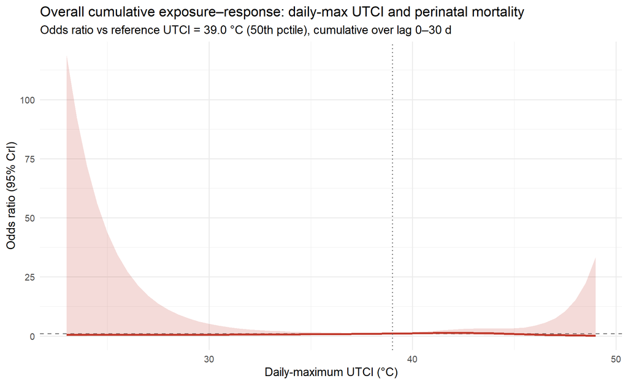

```r
# Overall cumulative exposure-response (summed across lags), OR vs reference.
overall <- tibble(
  utci = as.numeric(names(cp$allRRfit)),
  or   = cp$allRRfit,
  lo   = cp$allRRlow,
  hi   = cp$allRRhigh
)

ggplot(overall, aes(x = utci)) +
  geom_hline(yintercept = 1, linetype = 2, colour = "grey50") +
  geom_ribbon(aes(ymin = lo, ymax = hi), alpha = 0.18, fill = "#C0392B") +
  geom_line(aes(y = or), linewidth = 1, colour = "#C0392B") +
  geom_vline(xintercept = exp_ref, linetype = 3, colour = "grey40") +
  labs(
    title = "Overall cumulative exposure–response: daily-max UTCI and perinatal mortality",
    subtitle = sprintf("Odds ratio vs reference UTCI = %.1f °C (50th pctile), cumulative over lag 0–30 d", exp_ref),
    x = "Daily-maximum UTCI (°C)", y = "Odds ratio (95% CrI)"
  )
```

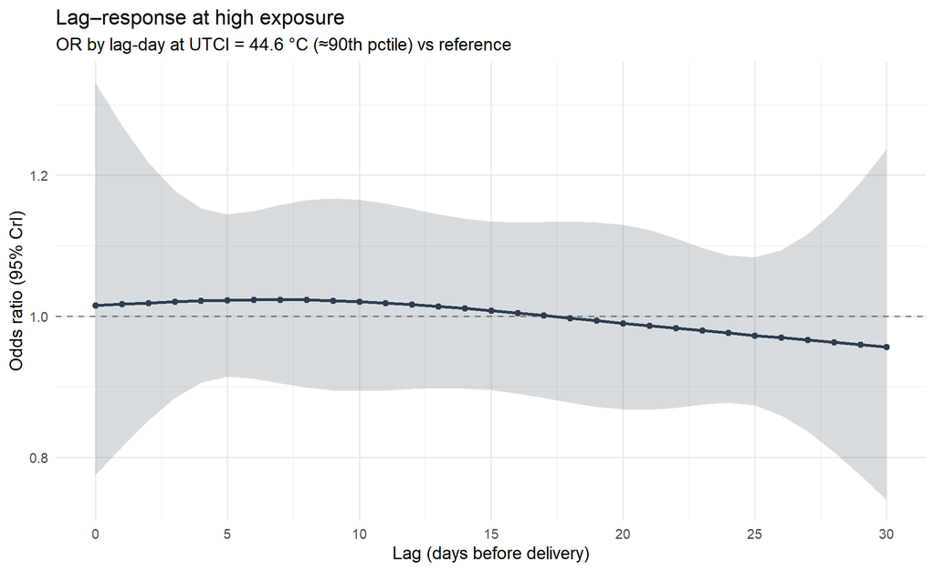

```r
# Lag-response at a high-exposure value (~90th percentile) vs reference.
# In dlnm::crosspred, matRRfit has predictor (exposure) values as ROWS and
# lags as COLUMNS: rownames are the 'at' values, colnames are "lag0".."lag30".
hi_exp <- quantile(Q, 0.90, na.rm = TRUE)
hi_lab <- as.character(round(hi_exp, 1))

at_vals  <- as.numeric(rownames(cp$matRRfit))
row_pick <- which.min(abs(at_vals - hi_exp))   # nearest available 'at' value

lagresp <- tibble(
  lag = LAG_MIN:LAG_MAX,
  or  = as.numeric(cp$matRRfit[row_pick, ]),
  lo  = as.numeric(cp$matRRlow[row_pick, ]),
  hi  = as.numeric(cp$matRRhigh[row_pick, ])
)

ggplot(lagresp, aes(x = lag)) +
  geom_hline(yintercept = 1, linetype = 2, colour = "grey50") +
  geom_ribbon(aes(ymin = lo, ymax = hi), alpha = 0.18, fill = "#2C3E50") +
  geom_line(aes(y = or), linewidth = 1, colour = "#2C3E50") +
  geom_point(aes(y = or), size = 1.6, colour = "#2C3E50") +
  scale_x_continuous(breaks = seq(LAG_MIN, LAG_MAX, 5)) +
  labs(
    title = "Lag–response at high exposure",
    subtitle = sprintf("OR by lag-day at UTCI = %s °C (≈90th pctile) vs reference", hi_lab),
    x = "Lag (days before delivery)", y = "Odds ratio (95% CrI)"
  )
```

# 6 Critical-window identification

A lag-day is flagged as a critical window when the posterior probability that its lag-specific effect is in the hypothesised (harmful) direction exceeds 0.95 — the Bayesian analogue of the frequentist windows-of-susceptibility test (Wilson et al. 2021). This is computed from the lag-response at high exposure.

```r
# Posterior probability (approx) that each lag-day OR > 1 at high exposure,
# from the normal approximation to the log-OR and its CrI half-width.
crit <- lagresp |>
  mutate(
    log_or   = log(or),
    se_log   = (log(hi) - log(lo)) / (2 * 1.96),
    p_harm   = 1 - pnorm(0, mean = log_or, sd = se_log),
    critical = p_harm >= 0.95
  )

nice_table(
  crit |>
    filter(critical) |>
    transmute(lag, OR = round(or, 3),
              CrI = sprintf("%.2f–%.2f", lo, hi),
              `P(OR>1)` = round(p_harm, 3)),
  caption = "Critical lag windows: days where the harmful-direction posterior probability exceeds 0.95 (at ~90th-percentile UTCI)."
)
```

Critical lag windows: days where the harmful-direction posterior probability exceeds 0.95 (at ~90th-percentile UTCI).

[output not shown]

```r
if (sum(crit$critical) == 0) {
  cat("No individual lag-day reached the 0.95 critical-window threshold at this exposure level.\n")
} else {
  rng <- range(crit$lag[crit$critical])
  cat(sprintf("Critical window spans lag %d to %d days before delivery.\n", rng[1], rng[2]))
}
```

```
#> No individual lag-day reached the 0.95 critical-window threshold at this exposure level.
```

# 7 Notes for downstream phases

- **Phase 4 (case-crossover triangulation)** reuses the same cross-basis definition (`exp_knots`, `LAG_KNOTS`) saved in `models/phase3_crosspred.rds`, so the cohort and case-crossover estimates are directly comparable.
- **Phase 6 (effect modification)** re-fits this model within the `anc_reliable == 1` sub-cohort with cross-basis × care-access interaction terms.
- **Phase 7 (sensitivity)** varies the lag window, the cross-basis df, the gestational-window assumption, and the prior specification, reusing the `model_df` assembled here.